# Fish_SuperRes

```python
import pandas as pd
from scipy.stats import binom_test, fisher_exact
from genepy.utils import helper as h
from scipy.spatial import distance_matrix
import pdb
import matplotlib.pyplot as plt
import seaborn as sns
import numpy as np
%load_ext autoreload
%autoreload 2
%load_ext rpy2.ipython
```

```
The autoreload extension is already loaded. To reload it, use:
  %reload_ext autoreload
The rpy2.ipython extension is already loaded. To reload it, use:
  %reload_ext rpy2.ipython
```

## Processing the data

```python
project='FishSuperResColoc'
version='v2'
```

```python
rename = {
"Text Between Delimiters":"subset",
"Folder Short":"folder_short",
"Folder Path":"folder",
"Source.Name":"name",
"ImageDocumentName::Image Name":"image",
"ParentID::ID of the parent!!I":"parent_id",
"ID::ID!!I":"id",
"RegionsCount::Count!!I": "count",
"ImageSceneName::Image Scene Name ":"scene",
"Area1::Area Unscaled!!R":"area_u",
"Area::Area!!R": "area",
"CenterX1::Center X Unscaled!!R":"x",
"CenterY1::Center Y Unscaled!!R":"y",
"ImageScaleX::Image Scale X!!R":"scale_x",
"ImageScaleY::Image Scale Y!!R":"scale_y",
"ImageIndexZ::Image Index Z!!I":"z",
'Classes 5 RegionsCount ::Classes 5 Count!!I':"count_red",
'Classes 9 RegionsCount ::Classes 9 Count!!I':"count_green",
"ClassColorName::Region Class Color Name": "class",
"IntensityMaximum_TV1-T1-SR::Intensity Maximum of channel 'TV1-T1-SR'!!R":"max_red",
"IntensityMaximum_TV2-T1-SR::Intensity Maximum of channel 'TV2-T1-SR'!!R":"max_tv2_t1",
"IntensityMaximum_TV2-T2-SR::Intensity Maximum of channel 'TV2-T2-SR'!!R":"max_green",
"IntensityMaximum_TV2-T3-SR::Intensity Maximum of channel 'TV2-T3-SR'!!R":"max_dapi",
"IntensityMean_TV1-T1-SR::Intensity Mean Value of channel 'TV1-T1-SR'!!R":"mean_red",
"IntensityMean_TV2-T1-SR::Intensity Mean Value of channel 'TV2-T1-SR'!!R":"mean_tv2_t1",
"IntensityMean_TV2-T2-SR::Intensity Mean Value of channel 'TV2-T2-SR'!!R":"mean_green",
"IntensityMean_TV2-T3-SR::Intensity Mean Value of channel 'TV2-T3-SR'!!R":"mean_dapi",
"IntensityMinimum_TV1-T1-SR::Intensity Minimum of channel 'TV1-T1-SR'!!R":"min_red",
"IntensityMinimum_TV2-T1-SR::Intensity Minimum of channel 'TV2-T1-SR'!!R":"min_tv2_t1",
"IntensityMinimum_TV2-T2-SR::Intensity Minimum of channel 'TV2-T2-SR'!!R":"min_green",
"IntensityMinimum_TV2-T3-SR::Intensity Minimum of channel 'TV2-T3-SR'!!R":"min_dapi",
"IntensitySum0_TV1-T1-SR::Intensity Pixel Count of channel 'TV1-T1-SR'!!R":"pixsum_red",
"IntensitySum0_TV2-T1-SR::Intensity Pixel Count of channel 'TV2-T1-SR'!!R":"pixsum_tv2_t1",
"IntensitySum0_TV2-T2-SR::Intensity Pixel Count of channel 'TV2-T2-SR'!!R":"pixsum_green",
"IntensitySum0_TV2-T3-SR::Intensity Pixel Count of channel 'TV2-T3-SR'!!R":"pixsum_dapi",
"IntensityRange_TV1-T1-SR::Intensity Range of channel 'TV1-T1-SR'!!R":"range_red",
"IntensityRange_TV2-T1-SR::Intensity Range of channel 'TV2-T1-SR'!!R":"range_tv2_t1",
"IntensityRange_TV2-T2-SR::Intensity Range of channel 'TV2-T2-SR'!!R":"range_green",
"IntensityRange_TV2-T3-SR::Intensity Range of channel 'TV2-T3-SR'!!R":"range_dapi",
"IntensityStd_TV1-T1-SR::Intensity Standard Deviation of channel 'TV1-T1-SR'!!R":"std_red",
"IntensityStd_TV2-T1-SR::Intensity Standard Deviation of channel 'TV2-T1-SR'!!R":"std_tv2_t1",
"IntensityStd_TV2-T2-SR::Intensity Standard Deviation of channel 'TV2-T2-SR'!!R":"std_green",
"IntensityStd_TV2-T3-SR::Intensity Standard Deviation of channel 'TV2-T3-SR'!!R":"std_dapi",
"IntensitySum1_TV1-T1-SR::Intensity Sum of channel 'TV1-T1-SR'!!R":"sum_red",
"IntensitySum1_TV2-T1-SR::Intensity Sum of channel 'TV2-T1-SR'!!R":"sum_tv2_t1",
"IntensitySum1_TV2-T2-SR::Intensity Sum of channel 'TV2-T2-SR'!!R":"sum_green",
"IntensitySum1_TV2-T3-SR::Intensity Sum of channel 'TV2-T3-SR'!!R":"sum_dapi",
"IntensitySum2_TV1-T1-SR::Intensity Sum Squares of channel 'TV1-T1-SR'!!R":"sum2_red",
"IntensitySum2_TV2-T1-SR::Intensity Sum Squares of channel 'TV2-T1-SR'!!R":"sum2_tv2_t1",
"IntensitySum2_TV2-T2-SR::Intensity Sum Squares of channel 'TV2-T2-SR'!!R":"sum2_green",
"IntensitySum2_TV2-T3-SR::Intensity Sum Squares of channel 'TV2-T3-SR'!!R":"sum2_dapi",
"Unnamed: 27":"unknown"
}
```

```python
data = pd.read_csv('../data/'+project+'/data_query_files/querry.csv').rename(columns=rename)
data
```

|  | subset | folder_short | folder | name | image | parent_id | id | scene | area | x | ... | sum_1 | sum_2 | range_1 | range_2 | std_1 | std_2 | sum1_1 | sum1_2 | sum2_1 | sum2_2 |
| --- | --- | --- | --- | --- | --- | --- | --- | --- | --- | --- | --- | --- | --- | --- | --- | --- | --- | --- | --- | --- | --- |
| 0 | Subset10 | AAVS1_CRISPR_MED1\AAVS1_CRISPR_MED1 Image7\ | C:\Users\M232498\Desktop\Ju\GDrive\IF FISH fin... | Image 7_Subset10_Out_Maximum intensity project... | NaN | NaN | NaN | NaN | pixel² | pixel | ... | pixel² | pixel² | Unknown | Unknown | Unknown | Unknown | Unknown | Unknown | Unknown² | Unknown² |
| 1 | Subset10 | AAVS1_CRISPR_MED1\AAVS1_CRISPR_MED1 Image7\ | C:\Users\M232498\Desktop\Ju\GDrive\IF FISH fin... | Image 7_Subset10_Out_Maximum intensity project... | Image 7_Subset10_Out_Maximum intensity project... | 14.0 | 15.0 | NaN | 7 | 368.64285714286 | ... | 7 | 7 | 1661 | 4080 | 547.72403548468 | 1510.241245314 | 49094 | 164490 | 346117272 | 3878964986 |
| 2 | Subset10 | AAVS1_CRISPR_MED1\AAVS1_CRISPR_MED1 Image7\ | C:\Users\M232498\Desktop\Ju\GDrive\IF FISH fin... | Image 7_Subset10_Out_Maximum intensity project... | Image 7_Subset10_Out_Maximum intensity project... | 14.0 | 16.0 | NaN | 28 | 396.21428571429 | ... | 28 | 28 | 8089 | 13818 | 2760.2006509669 | 3701.1435641623 | 123989 | 523204 | 754750539 | 10146373720 |
| 3 | Subset10 | AAVS1_CRISPR_MED1\AAVS1_CRISPR_MED1 Image7\ | C:\Users\M232498\Desktop\Ju\GDrive\IF FISH fin... | Image 7_Subset10_Out_Maximum intensity project... | Image 7_Subset10_Out_Maximum intensity project... | 14.0 | 17.0 | NaN | 13 | 426.88461538462 | ... | 13 | 13 | 4583 | 6576 | 1313.3590522016 | 2101.7813019022 | 108303 | 285907 | 922971237 | 6340918481 |
| 4 | Subset10 | AAVS1_CRISPR_MED1\AAVS1_CRISPR_MED1 Image7\ | C:\Users\M232498\Desktop\Ju\GDrive\IF FISH fin... | Image 7_Subset10_Out_Maximum intensity project... | Image 7_Subset10_Out_Maximum intensity project... | 14.0 | 18.0 | NaN | 29 | 340.74137931035 | ... | 29 | 29 | 3515 | 12083 | 1077.0374837392 | 3107.8328355138 | 196046 | 460225 | 1357791794 | 7574132899 |
| ... | ... | ... | ... | ... | ... | ... | ... | ... | ... | ... | ... | ... | ... | ... | ... | ... | ... | ... | ... | ... | ... |
| 117757 | Subset9 | IF FISH final\Runx2_excel\ | C:\Users\M232498\Desktop\Ju\GDrive\IF FISH fin... | Runx2_488_MYC_FISH_SIM-Orthogonal Projection-0... | Runx2_488_MYC_FISH_SIM-Orthogonal Projection-0... | 1.0 | 23.0 | NaN | 55230 | 1146.4196089082 | ... | NaN | NaN | NaN | NaN | NaN | NaN | NaN | NaN | NaN | NaN |
| 117758 | Subset9 | IF FISH final\Runx2_excel\ | C:\Users\M232498\Desktop\Ju\GDrive\IF FISH fin... | Runx2_488_MYC_FISH_SIM-Orthogonal Projection-0... | Runx2_488_MYC_FISH_SIM-Orthogonal Projection-0... | 1.0 | 24.0 | NaN | 60384 | 1546.5754835718 | ... | NaN | NaN | NaN | NaN | NaN | NaN | NaN | NaN | NaN | NaN |
| 117759 | Subset9 | IF FISH final\Runx2_excel\ | C:\Users\M232498\Desktop\Ju\GDrive\IF FISH fin... | Runx2_488_MYC_FISH_SIM-Orthogonal Projection-0... | Runx2_488_MYC_FISH_SIM-Orthogonal Projection-0... | 1.0 | 25.0 | NaN | 48042 | 2480.9880521211 | ... | NaN | NaN | NaN | NaN | NaN | NaN | NaN | NaN | NaN | NaN |
| 117760 | Subset9 | IF FISH final\Runx2_excel\ | C:\Users\M232498\Desktop\Ju\GDrive\IF FISH fin... | Runx2_488_MYC_FISH_SIM-Orthogonal Projection-0... | Runx2_488_MYC_FISH_SIM-Orthogonal Projection-0... | 1.0 | 26.0 | NaN | 70306 | 1932.6927004808 | ... | NaN | NaN | NaN | NaN | NaN | NaN | NaN | NaN | NaN | NaN |
| 117761 | Subset9 | IF FISH final\Runx2_excel\ | C:\Users\M232498\Desktop\Ju\GDrive\IF FISH fin... | Runx2_488_MYC_FISH_SIM-Orthogonal Projection-0... | Runx2_488_MYC_FISH_SIM-Orthogonal Projection-0... | 1.0 | 27.0 | NaN | 68115 | 129.92614695735 | ... | NaN | NaN | NaN | NaN | NaN | NaN | NaN | NaN | NaN | NaN |

117762 rows × 27 columns

```python
data.columns
```

```
Index(['subset', 'folder_short', 'folder', 'name', 'image', 'parent_id', 'id',
       'scene', 'area', 'x', 'y', 'max_1', 'max_2', 'mean_1', 'mean_2',
       'min_1', 'min_2', 'sum_1', 'sum_2', 'range_1', 'range_2', 'std_1',
       'std_2', 'sum1_1', 'sum1_2', 'sum2_1', 'sum2_2'],
      dtype='object')
```

```python
cat ../data/$project/data_query_files/querry.csv | less
```

```
Text Between Delimiters,Folder Short,Folder Path,Source.Name,ImageDocumentName::Image Name,ParentID::ID of the parent!!I,ID::ID!!I,ImageSceneName::Image Scene Name ,Area1::Area Unscaled!!R,CenterX1::Center X Unscaled!!R,CenterY1::Center Y Unscaled!!R,IntensityMaximum_TV1-T1-SR::Intensity Maximum of …
Subset10,AAVS1_CRISPR_MED1\AAVS1_CRISPR_MED1 Image7\,C:\Users\M232498\Desktop\Ju\GDrive\IF FISH final\AAVS1_CRISPR_MED1\AAVS1_CRISPR_MED1 Image7\,Image 7_Subset10_Out_Maximum intensity projection__ Green Dots.csv,,,,,pixel²,pixel,pixel,Unknown,Unknown,Unknown,Unknown,Unknown,Unknown,pixel²,pixel²,Un…
:
```

```python
data.iloc[0].tolist()
```

```python
set(data.folder_short)
```

```python
cond = {'AAVS1_CRISPR_MED1\\AAVS1_CRISPR_MED1 Image7\\':'AAVS1',
 'IF FISH final\\AAVS1_CRISPR_MEF2D\\':'AAVS1',
 'IF FISH final\\IRF2BP2_excel\\':'',
 'IF FISH final\\MEF2C_excel\\':'',
 'IF FISH final\\MEF2D_CRISPR_MED1\\':'MEF2D',
 'IF FISH final\\MEF2D_CRISPR_MEF2D\\':'MEF2D',
 'IF FISH final\\Runx2_excel\\':''}
```

```python
prot = {'AAVS1_CRISPR_MED1\\AAVS1_CRISPR_MED1 Image7\\':'MED1',
 'IF FISH final\\AAVS1_CRISPR_MEF2D\\':'MEF2D',
 'IF FISH final\\IRF2BP2_excel\\':'IRF2BP2',
 'IF FISH final\\MEF2C_excel\\':'MEF2C',
 'IF FISH final\\MEF2D_CRISPR_MED1\\':'MED1',
 'IF FISH final\\MEF2D_CRISPR_MEF2D\\':'MEF2D',
 'IF FISH final\\Runx2_excel\\':'RUNX2'}
```

```python
data = data[~data.name.str.contains('Classes')]
```

```python
data['condition'] = [cond[i] for i in data.folder_short]
```

```python
data['protein'] = [prot[i] for i in data.folder_short]
```

```python
data['type'] = [i.split('.')[0].split('_')[-1] for i in data.name]
```

```python
data['name'] = [cond[i]+'_'+prot[i] for i in data.folder_short]
```

```python
set(data.type)
```

```python
data = data[~data.id.isna()]
```

```python
set(data.subset)
```

```python
data = data.drop(columns=['scene','image','folder','folder_short'])
```

```python
data['subset'] = [i.split('Subset')[-1] for i in data.subset]
```

```python
for val in ['area','x','y','max_1','max_2','mean_1','mean_2','min_1','min_2','range_1','range_2','std_1','std_2','sum_1','sum_2','sum1_1','sum1_2','sum2_1','sum2_2']:
    data[val]= data[val].astype(float)
```

```python
for val in ['subset','parent_id','id']:
    data[val] = data[val].astype('int')
```

```python
len(data.id)
```

# results

## why we are not doing a monte carlo but just a hypthesis testing on a binomial

monte carlo would be useful in our case if we did not know the expected distribution. given a way to generate our distribution (which specific parameters can be learnt from the data) we might be able to express what would be the null hypothesis by estimating this unknown distribution. it is useful for when we don't know the exact distribution or when it is too complex to analytically solve.

However in our case we can approximate the distribution well enough by a binomial. It is true that given that the dna will not have the same density everywhere on the nucleus, that the dots will have themselves variable intensity and size, which might express or not a multiplicity of points, the distribution is not a binomial.

But you said yourself that for all purposes we could simplify these hypothesis.

I also don't think that we have enough data points to correctly estimate the monte carlo parameters.

A binomial is thus enough for this analysis

### having specificities in the data needing to be modelled:

I found that the data has specific bias that still need to be taken in account while not needing to change the statistics:

the avg size of a MYC dot is 350 whereas the one of a MYC green is 45

```python
def desc(data):
    return data.sum()/data.mean(),len(data)
# for each group
res = {}
for val in set(data.name):
    print('\n',val)
    group = data[data.name==val]
    space = group[group.type=='Nucleus'].area.sum()
    totsize = group[group.type==' Green Dots'].area.sum()

    coloc,s_coloc = desc(group[group.type=='MYC  Green'].area)
    outside,s_outside = desc(group[group.type=='MYC'].area)
    print('data: \n  - total nucleuses size: '+str(int(space))+'\n  - total Green dot size: '+str(int(totsize))+'\n  - counts for coloc: '+str(int(s_coloc))+'\n  - counts for not coloc: '+str(int(s_outside)))
    p_in = totsize/space
    isin = coloc/(outside+coloc)
    res[val] = [s_coloc,s_outside]
    print('proba: (null, obs)',p_in,isin)
    print('nb of datapoints: ',s_coloc+s_outside)
    print('p_value: ',binom_test([s_coloc,s_outside],p=p_in))
```

[output not shown]

```python
fisher_exact([res['AAVS1_MED1'], res['MEF2D_MED1']])
```

```python
fisher_exact([res['AAVS1_MEF2D'], res['MEF2D_MEF2D']])
```

## running new version

```python
#TODO: compare intensities & areas between conditions
```

```python
project='FishSuperResColoc'
version='v3'
```

```python
csvs = ! ls ../data/$project/Yaser3/*/*.csv
res = pd.DataFrame()
for val in csvs:
    v = pd.read_csv(val,).drop(index=0)
    v['filename'] = '-'.join(val.split('/')[-2].split('-')[2:-1])
    res = res.append(v)
res = res.rename(columns=rename)
res.parent_id = res.parent_id.astype(int)
res.id = res.id.astype(int)
res.area = res.area.astype(float)
res = res.reset_index(drop=True)
```

```python
res["zsize"] = 1
```

```python
values =  ['area', 'x', 'y', "z", "scale_x", "scale_y", "count_red", "count_green", "max_red", "max_green", "max_dapi", "mean_red", "mean_green", "mean_dapi", "min_red", "min_green", "min_dapi", "pixsum_red", "pixsum_green", "pixsum_dapi", "range_red", "range_green", "range_dapi", "std_red", "std_green", "std_dapi", "sum_red", "sum_green", "sum_dapi", "sum2_red", "sum2_green", "sum2_dapi"]
res[values] = pd.concat([res[i].astype(str).str.replace('  ','0').replace(' ','0').replace('', '0').replace('None',"0").astype(float) for i in values], axis=1)
res['x']= res['x']*res["scale_x"]
res['y']= res['y']*res["scale_y"]
res = res.drop(columns=['area_u',"scale_x",'scale_y'])
set(['-'.join(i.split('/')[-3].split('-')[1:]) for i in csvs])
```

```
{''}
```

TV2-T3: Dapi

TV1-T1: red

TV2-T2: green

```python
res["new_id"]= res['filename'] + "--" + res['image'].str.split('Alignment_P').str[-1].str.replace('_Subset.czi',"")+"--"+res['id'].astype(str)+"--"+res['parent_id'].astype(str)
```

```python
res['group']
```

```
0        MED1-MYC_MEF2D-DMSO--1-1
1        MED1-MYC_MEF2D-DMSO--1-1
2        MED1-MYC_MEF2D-DMSO--1-1
3        MED1-MYC_MEF2D-DMSO--1-1
4        MED1-MYC_MEF2D-DMSO--1-1
                   ...
45179    MED1-MYC_MEF2D-DMSO--4-2
45180    MED1-MYC_MEF2D-DMSO--4-2
45181    MED1-MYC_MEF2D-DMSO--4-2
45182    MED1-MYC_MEF2D-DMSO--4-2
45183    MED1-MYC_MEF2D-DMSO--4-2
Name: group, Length: 45184, dtype: object
```

```python
res['group'] = res['filename'] + "--" + res['image'].str.split('Alignment_P').str[-1].str.replace('_Subset.czi',"")
```

```python
res['parent_id'] = [i.split('--')[-1] for i in res.new_id]
res['exp'] = [i.split('-')[2] for i in res.group]
res['treat'] = [i.split('-')[0] for i in res.group]
#res['image'] = [i.split('--')[-1].split('_')[0] for i in res.group]
res['part'] = [i.split('--')[-1] for i in res.group]
res['id'] = [i.split('--')[-2] for i in res.new_id]
set(res.exp)
```

```
{'DMSO'}
```

```python
res['class'] = res['class'].replace({'Orange':"dapi", 'Fuchsia': "green", "White": 'red'})
```

```python
res = res.drop(index=res[res['class'].isna()].index)
```

```python
vals=['parent_id',"id","area","x",'y',"z","count_red","count_green"]
res[vals] = res[vals].astype(int)
```

```python
res.to_csv('../results/'+project+"/"+version+"_yaserdata.csv")
```

```python
res = pd.read_csv('../results/'+project+"/"+version+"_yaserdata.csv", index_col=0)
```

```python
res[((res["parent_id"]==1)&(res['area']>27500000))]
```

|  | image | parent_id | id | area | x | y | z | class | count_red | count_green | ... | sum2_red | sum2_green | sum2_dapi | filename | zsize | new_id | group | exp | treat | part |
| --- | --- | --- | --- | --- | --- | --- | --- | --- | --- | --- | --- | --- | --- | --- | --- | --- | --- | --- | --- | --- | --- |
| 0 | Image 13_SIM_Channel Alignment_P1-1_Subset.czi | 1 | 2 | 98065857 | 6213 | 6522 | 1 | dapi | 0 | 0 | ... | 0.0 | 0.0 | 0.0 | MED1-MYC_MEF2D-DMSO | 1 | MED1-MYC_MEF2D-DMSO--1-1--2--1 | MED1-MYC_MEF2D-DMSO--1-1 | DMSO | MED1 | 1-1 |
| 1 | Image 13_SIM_Channel Alignment_P1-1_Subset.czi | 1 | 2 | 95940509 | 6184 | 6517 | 2 | dapi | 0 | 0 | ... | 0.0 | 0.0 | 0.0 | MED1-MYC_MEF2D-DMSO | 1 | MED1-MYC_MEF2D-DMSO--1-1--2--1 | MED1-MYC_MEF2D-DMSO--1-1 | DMSO | MED1 | 1-1 |
| 2 | Image 13_SIM_Channel Alignment_P1-1_Subset.czi | 1 | 2 | 93532957 | 6174 | 6452 | 3 | dapi | 0 | 0 | ... | 0.0 | 0.0 | 0.0 | MED1-MYC_MEF2D-DMSO | 1 | MED1-MYC_MEF2D-DMSO--1-1--2--1 | MED1-MYC_MEF2D-DMSO--1-1 | DMSO | MED1 | 1-1 |
| 3 | Image 13_SIM_Channel Alignment_P1-1_Subset.czi | 1 | 2 | 93260552 | 6195 | 6522 | 4 | dapi | 0 | 0 | ... | 0.0 | 0.0 | 0.0 | MED1-MYC_MEF2D-DMSO | 1 | MED1-MYC_MEF2D-DMSO--1-1--2--1 | MED1-MYC_MEF2D-DMSO--1-1 | DMSO | MED1 | 1-1 |
| 4 | Image 13_SIM_Channel Alignment_P1-1_Subset.czi | 1 | 2 | 90822624 | 6221 | 6490 | 5 | dapi | 0 | 0 | ... | 0.0 | 0.0 | 0.0 | MED1-MYC_MEF2D-DMSO | 1 | MED1-MYC_MEF2D-DMSO--1-1--2--1 | MED1-MYC_MEF2D-DMSO--1-1 | DMSO | MED1 | 1-1 |
| ... | ... | ... | ... | ... | ... | ... | ... | ... | ... | ... | ... | ... | ... | ... | ... | ... | ... | ... | ... | ... | ... |
| 45178 | Image 13_SIM_Channel Alignment_P4-2_Subset.czi | 1 | 3 | 96269747 | 19585 | 11575 | 97 | dapi | 0 | 1 | ... | 0.0 | 0.0 | 0.0 | MED1-MYC_MEF2D-DMSO | 1 | MED1-MYC_MEF2D-DMSO--4-2--3--1 | MED1-MYC_MEF2D-DMSO--4-2 | DMSO | MED1 | 4-2 |
| 45180 | Image 13_SIM_Channel Alignment_P4-2_Subset.czi | 1 | 2 | 186603414 | 14641 | 10575 | 98 | dapi | 0 | 0 | ... | 0.0 | 0.0 | 0.0 | MED1-MYC_MEF2D-DMSO | 1 | MED1-MYC_MEF2D-DMSO--4-2--2--1 | MED1-MYC_MEF2D-DMSO--4-2 | DMSO | MED1 | 4-2 |
| 45181 | Image 13_SIM_Channel Alignment_P4-2_Subset.czi | 1 | 2 | 186963028 | 14590 | 10530 | 99 | dapi | 0 | 0 | ... | 0.0 | 0.0 | 0.0 | MED1-MYC_MEF2D-DMSO | 1 | MED1-MYC_MEF2D-DMSO--4-2--2--1 | MED1-MYC_MEF2D-DMSO--4-2 | DMSO | MED1 | 4-2 |
| 45182 | Image 13_SIM_Channel Alignment_P4-2_Subset.czi | 1 | 2 | 186349626 | 14582 | 10503 | 100 | dapi | 0 | 0 | ... | 0.0 | 0.0 | 0.0 | MED1-MYC_MEF2D-DMSO | 1 | MED1-MYC_MEF2D-DMSO--4-2--2--1 | MED1-MYC_MEF2D-DMSO--4-2 | DMSO | MED1 | 4-2 |
| 45183 | Image 13_SIM_Channel Alignment_P4-2_Subset.czi | 1 | 2 | 192630623 | 14617 | 10518 | 101 | dapi | 0 | 0 | ... | 0.0 | 0.0 | 0.0 | MED1-MYC_MEF2D-DMSO | 1 | MED1-MYC_MEF2D-DMSO--4-2--2--1 | MED1-MYC_MEF2D-DMSO--4-2 | DMSO | MED1 | 4-2 |

2048 rows × 41 columns

```python
res = res[((res["parent_id"]==1)&(res['area']>27500000))|(res["parent_id"]!=1)]
```

```python
def mergeZStack(res, zsize=25, groupcol="group", pidcol="parent_id", idcol="id", xcol="x", ycol="y", zcol="z", areacol="area", redcol="count_red", greencol="count_green", classcol="class", checks=False, maxzheight=10, maxdist=500):
    groups = set(res[groupcol])
    for group in groups:
        subres = res[res[groupcol] == group]
        dots = subres[subres[pidcol] != 1]
        # merging cells
        cells = subres[subres[pidcol] == 1]
        idcells = set(cells[idcol])
        rn = dict.fromkeys(set(cells.columns), "first")
        rn.update({
            xcol: "mean",
            ycol: "mean",
            zcol: ['min', 'max'],
            areacol: "sum",
            redcol: "sum",
            greencol: "sum",
        })

        if checks:
            for idcell in idcells:
                a = 0
                c = cells[cells[idcol]==idcell]
                for i in c[zcol].tolist():
                    if (i > a+maxzheight or i==a) and a !=0:
                        print(ValueError("too much z distance between same cell: "+ str(idcell) +" "+ group + " "+str(a-i)))
                    a=i
                # do they match in xy coor
                loc = np.diagonal(distance_matrix(c[[xcol,ycol]].values, c[[xcol,ycol]].values,1)) > maxdist
                if np.any(loc):
                    cid = c.iloc[np.argwhere(loc).T[0]][idcol]
                    raise ValueError('the  x,y distance is too important between two z adjacent cell centers: '+ str(idcell) +" "+group+ " "+ str(cid))

        cells = cells.groupby(idcol).agg(rn)
        cells[areacol] = cells[areacol]*zsize

        # dots now
        rn.update({
            'max_red': "max",
            'max_green': "max",
            'max_dapi': "max",
            'mean_red': "mean",
            'mean_green': "mean",
            'mean_dapi': "mean",
            'min_red': "min",
            'min_green': "min",
            'min_dapi': "min",
            'pixsum_red': "sum",
            'pixsum_green': "sum",
            'pixsum_dapi': "sum",
            'range_red': "mean",
            'range_green': "mean",
            'range_dapi': "mean",
            'std_red': "mean",
            'std_green': "mean",
            'std_dapi': "mean",
            'sum_red': "mean",
            'sum_green': "mean",
            'sum_dapi': "mean",
            'sum2_red': "mean",
            'sum2_green': "mean",
            'sum2_dapi': "mean"
        })
        iddots = set(dots[idcol])
        if checks:
            # do they match in zsize
            for iddot in iddots:
                a = 0
                d = dots[dots[idcol]==iddot]
                for i in d[zcol].tolist():
                    if (i > a+maxzheight or i==a) and a !=0:
                        raise ValueError("too much z distance between same dot: "+ str(iddot) +" "+ group + " "+str(a-i))
                    a=i
                    # do they match in parent_id
                    if len(set(d[pidcol]))>1:
                        raise ValueError("multiple parent_ids: "+group)
                    if len(set(d[classcol]))>1:
                        raise ValueError("multiple parent_ids: "+group)

                # do they match in xy coor
                loc = np.diagonal(distance_matrix(d[[xcol,ycol]].values, d[[xcol,ycol]].values),1) > maxdist
                #pdb.set_trace()
                if np.any(loc):
                    did = d.iloc[np.argwhere(loc).T[0]].index.tolist()
                    raise ValueError('the x,y distance is too important between two z adjacent dot centers: '+str(iddot) +" "+group+ " "+ str(did))

        dots = dots.groupby(idcol).agg(rn)
```

```python
np.sqrt((5659-6753)**2 + (8586-4600)**2)
```

```
4133.404407991069
```

```python
np.sqrt(39194/3.14)
```

```
111.72361256733305
```

```python
subres[subres.id==4]
```

[output not shown]

18 rows × 41 columns

```python
subres[subres.z==54]
```

[output not shown]

2 rows × 42 columns

```python
for val in set(res.parent_id):
    print(val, Counter(res[res.parent_id==val]['class']))
```

[output not shown]

[output cut: 56 more lines]

[output not shown]

```python
mergeZStack(subres, checks=True)
```

```
too much z distance between same cell: 2 MED1-MYC_MEF2D-DMSOvsVHL-wDMSO--13_SIM_1-1 -24
too much z distance between same cell: 2 MED1-MYC_MEF2D-DMSOvsVHL-wDMSO--13_SIM_1-1 -16
too much z distance between same cell: 3 MED1-MYC_MEF2D-DMSOvsVHL-wDMSO--13_SIM_1-1 -24
too much z distance between same cell: 4 MED1-MYC_MEF2D-DMSOvsVHL-wDMSO--13_SIM_1-1 -64
too much z distance between same cell: 4 MED1-MYC_MEF2D-DMSOvsVHL-wDMSO--13_SIM_1-1 -11
too much z distance between same cell: 5 MED1-MYC_MEF2D-DMSOvsVHL-wDMSO--13_SIM_1-1 -11
too much z distance between same cell: 5 MED1-MYC_MEF2D-DMSOvsVHL-wDMSO--13_SIM_1-1 -77
```

[output not shown]

```python
subres = res[res.group=="MED1-MYC_MEF2D-DMSOvsVHL-wDMSO--13_SIM_1-1"]
```

```python
from collections import Counter
```

```python
Counter(subres[subres['class']=='green'].parent_id)
```

```
Counter({14: 2, 8: 4, 10: 6, 11: 2, 7: 69, 4: 181, 5: 6, 9: 8, 6: 7})
```

```python
Counter(subres[subres['class']=='dapi'].id)
```

```
Counter({5: 7, 3: 41, 2: 57, 4: 17, 7: 2, 6: 4, 8: 1})
```

```python
cells = res[res["parent_id"]==1].reset_index(drop=True)
dots = res[res["parent_id"]!=1].reset_index(drop=True)
cells[['count_red','count_green']].mean()
```

```
count_red      0.028077
count_green    0.056730
dtype: float64
```

```python
set(dots['class']),set(cells['class'])
```

```
({'green', 'red'}, {'dapi'})
```

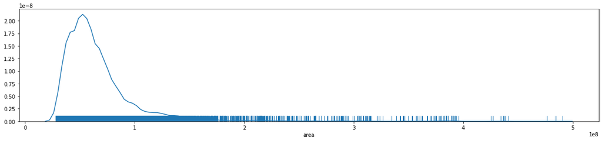

```python
_, ax = plt.subplots(figsize=(20,4))
sns.distplot(cells[cells.area>27500000].area, ax=ax, rug=True, hist=False)
```

```python
print(len(cells),len(dots))
cells = cells[cells.area>27500000].reset_index(drop=True)
print(len(cells),len(dots))
```

[output not shown]

[output not shown]

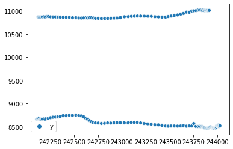

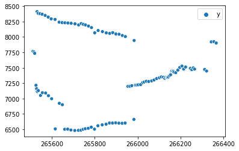

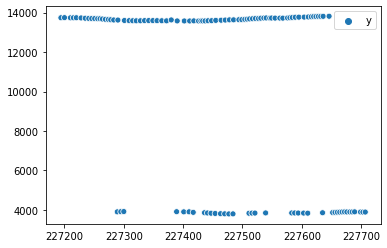

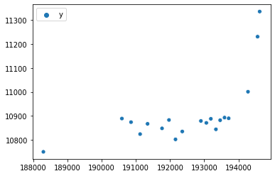

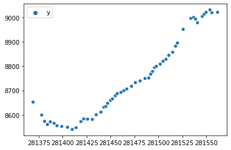

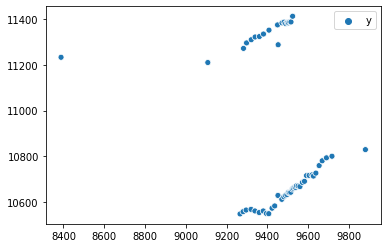

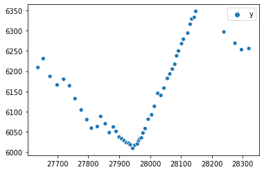

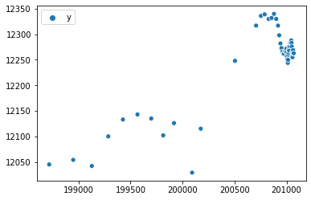

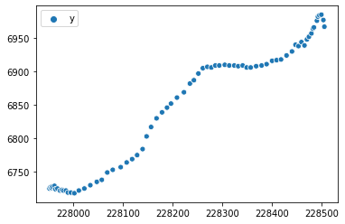

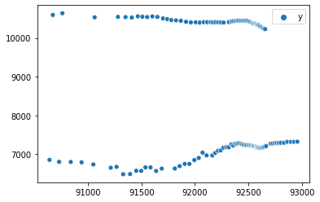

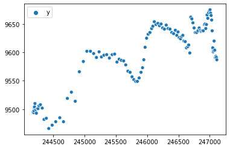

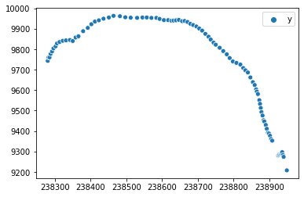

[89 more figures not shown]

```python
for val in set(cells.group):
    sns.scatterplot(data=cells[cells.area>27500000][cells.group==val][(cells.count_green>0)|(cells.count_red>0)][['x','y']])
    plt.show()
```

```python
%store dots
%store cells
```

```
Stored 'dots' (DataFrame)
Stored 'cells' (DataFrame)
```

```python
%store -r dots
%store -r cells
```

```python
dots[(dots.group=='MEF2D-MEF2C_DMSOvsVHL-wDMSO--8_Out_4-2')&(dots.z==45)]
```

|  | image | parent_id | id | area | x | y | z | class | count_red | count_green | ... | sum2_red | sum2_green | sum2_dapi | filename | zsize | new_id | group | exp | treat | part |
| --- | --- | --- | --- | --- | --- | --- | --- | --- | --- | --- | --- | --- | --- | --- | --- | --- | --- | --- | --- | --- | --- |
| 14491 | 8 | 4 | 5 | 7838 | 5282 | 6158 | 45 | green | 0 | 0 | ... | 299693157.0 | 133840470.0 | 473308584.0 | MEF2D-MEF2C_DMSOvsVHL-wDMSO | 1 | MEF2D-MEF2C_DMSOvsVHL-wDMSO--8_Out_4-2--5--4 | MEF2D-MEF2C_DMSOvsVHL-wDMSO--8_Out_4-2 | MEF2D-MEF2C_DMSOvsVHL | DMSO | 4-2 |

1 rows × 41 columns

```python
cells[(cells.group=='MEF2D-MEF2C_DMSOvsVHL-wDMSO--8_Out_4-2')&(cells.z==45)]
```

|  | image | parent_id | id | area | x | y | z | class | count_red | count_green | ... | sum2_red | sum2_green | sum2_dapi | filename | zsize | new_id | group | exp | treat | part |
| --- | --- | --- | --- | --- | --- | --- | --- | --- | --- | --- | --- | --- | --- | --- | --- | --- | --- | --- | --- | --- | --- |
| 214174 | 8 | 1 | 2 | 37027504 | 6401 | 7026 | 45 | dapi | 0 | 1 | ... | 0.0 | 0.0 | 0.0 | MEF2D-MEF2C_DMSOvsVHL-wDMSO | 1 | MEF2D-MEF2C_DMSOvsVHL-wDMSO--8_Out_4-2--2--1 | MEF2D-MEF2C_DMSOvsVHL-wDMSO--8_Out_4-2 | MEF2D-MEF2C_DMSOvsVHL | DMSO | 4-2 |

1 rows × 41 columns

```python
_relabelCells(cm,  cells, dots)
```

[output not shown]

[output cut: 178 more lines]

[output not shown]

[output not shown]

```python
cm = _mergeCells(cells)
```

[output not shown]

[output cut: 46 more lines]

```
MED1-MYC_MEF2D-DMSOvsVHL-wDMSO--13_SIM_2-2
MEF2D-MEF2C_DMSOvsVHL-wDMSO--8_Out_2-2
MEF2D-MEF2C_DMSOvsVHL-wVHL--28_Out_2-5
MEF2C-MYC_MEF2D-DMSOvsVHL-wVHL--26_Out_5-2
MED1-MYC_MEF2D-DMSOvsVHL-wDMSO--4_SIM_3-2
MEF2C-MYC_MEF2D-DMSOvsVHL-wDMSO--12_Out_4-7
MEF2C-MYC_MEF2D-DMSOvsVHL-wVHL--26_Out_3-1
MED1-MYC_MEF2D-DMSOvsVHL-wDMSO--4_SIM_1-1
MEF2D-MEF2C_DMSOvsVHL-wDMSO--8_Out_2-6
MED1-MYC_MEF2D-DMSOvsVHL-wDMSO--13_SIM_4-1
MED1-MYC_MEF2D-DMSOvsVHL-wDMSO--13_SIM_2-5
MED1-MYC_MEF2D-DMSOvsVHL-wVHL--11_Out_3
MEF2D-MEF2C_DMSOvsVHL-wDMSO--8_Out_1-2
MED1-MYC_MEF2D-DMSOvsVHL-wDMSO--13_SIM_3-3
MEF2D-MEF2C_DMSOvsVHL-wVHL--28_Out_3-1
```

```python
pixsize = 20 # size of a pixel in nm
```

```python
# do the same for dots
maxid = 0
for group in set(res.group):

    # merging cells
    gdots = dots[(dots.group==group)]
    cid = list(set(gdots.id.astype(int)))

    # unique ids
    for c in ['likely_green', "likely_red"]:
        prevzdots = False
        for z in set(gdots.z):
            zdots = gdots[(gdots.z==z) & gdots[c]]
            if len(set(Counter(zdots.id).values())) > 2:
                raise ValueError('multiple of the same id', z, group, Counter(zdots.id))

            if prevzdots:
                smaller = np.array([np.sqrt(np.sum((zdots[['x','y']].values - np.array(val))**2, 1)) for val in prevzdots[['x','y']].values])
                rad = np.sqrt(zdots.area/3.14)/pixsize

                smallerloc = np.argmin(smaller, 0)
                prevdotsloc = np.argwhere(smaller[smallerloc]<rad*2)
                newdotsloc = np.argwhere(smaller[smallerloc]>=rad*2)

                # we reassign right ids:
                dots.loc[zdots.iloc[prevdotsloc].index, 'id'] = prevzdots.iloc[smallerloc].id.tolist()

                #we create new ids:
                dots.loc[zdots.iloc[newdotsloc].index, 'id'] = range(maxid, len(newdotsloc) + maxid)
                maxid += len(newdotsloc)
            else:
                prevzdots = zdots.copy()
                maxid = max(zdots.id) if maxid==0 else len(zdots.id) + maxid
```

[output not shown]

```python
dots[(dots.id==10)&(dots.group=="VHL_MEF2D-MYC-wVHL--5_SIM_1-4")&(dots.likely_green)]
```

|  | image | parent_id | id | area | x | y | z | count_red | count_green | max_red | ... | sum_green | sum_dapi | sum2_red | sum2_green | sum2_dapi | filename | zsize | group | likely_green | likely_red |
| --- | --- | --- | --- | --- | --- | --- | --- | --- | --- | --- | --- | --- | --- | --- | --- | --- | --- | --- | --- | --- | --- |
| 3359 | Image 5_SIM_Channel Alignment_P1-4.czi | 9 | 10 | 27436.491004 | 421.392857 | 369.357143 | 0.0 | 0.0 | 0.0 | 215.0 | ... | 43747.0 | 16318.0 | 275995.0 | 70211141.0 | 19668578.0 | VHL_MEF2D-MYC-wVHL | 1 | VHL_MEF2D-MYC-wVHL--5_SIM_1-4 | 1.0 | 0.0 |
| 3364 | Image 5_SIM_Channel Alignment_P1-4.czi | 9 | 10 | 40174.861827 | 421.426829 | 368.426829 | 0.0 | 0.0 | 0.0 | 215.0 | ... | 68819.0 | 20085.0 | 251952.0 | 123563765.0 | 26592255.0 | VHL_MEF2D-MYC-wVHL | 1 | VHL_MEF2D-MYC-wVHL--5_SIM_1-4 | 1.0 | 0.0 |
| 3435 | Image 5_SIM_Channel Alignment_P1-4.czi | 6 | 10 | 36255.363112 | 283.554054 | 134.175676 | 0.0 | 0.0 | 0.0 | 884.0 | ... | 155818.0 | 31754.0 | 18031843.0 | 707083746.0 | 66132002.0 | VHL_MEF2D-MYC-wVHL | 1 | VHL_MEF2D-MYC-wVHL--5_SIM_1-4 | 1.0 | 0.0 |
| 3483 | Image 5_SIM_Channel Alignment_P1-4.czi | 8 | 10 | 25476.741646 | 472.500000 | 409.000000 | 0.0 | 0.0 | 0.0 | 665.0 | ... | 55697.0 | 40129.0 | 1645868.0 | 124637469.0 | 136373691.0 | VHL_MEF2D-MYC-wVHL | 1 | VHL_MEF2D-MYC-wVHL--5_SIM_1-4 | 1.0 | 0.0 |
| 3540 | Image 5_SIM_Channel Alignment_P1-4.czi | 9 | 10 | 42134.611184 | 475.058140 | 361.941860 | 0.0 | 0.0 | 0.0 | 243.0 | ... | 99459.0 | 140766.0 | 170964.0 | 260083743.0 | 538325238.0 | VHL_MEF2D-MYC-wVHL | 1 | VHL_MEF2D-MYC-wVHL--5_SIM_1-4 | 1.0 | 0.0 |
| 3545 | Image 5_SIM_Channel Alignment_P1-4.czi | 9 | 10 | 43114.485863 | 475.000000 | 361.727273 | 0.0 | 0.0 | 0.0 | 164.0 | ... | 99854.0 | 160497.0 | 94404.0 | 257239838.0 | 683204027.0 | VHL_MEF2D-MYC-wVHL | 1 | VHL_MEF2D-MYC-wVHL--5_SIM_1-4 | 1.0 | 0.0 |
| 3643 | Image 5_SIM_Channel Alignment_P1-4.czi | 9 | 10 | 49973.608614 | 298.029412 | 438.931373 | 0.0 | 0.0 | 0.0 | 367.0 | ... | 100693.0 | 177896.0 | 700279.0 | 227600855.0 | 925889886.0 | VHL_MEF2D-MYC-wVHL | 1 | VHL_MEF2D-MYC-wVHL--5_SIM_1-4 | 1.0 | 0.0 |

7 rows × 38 columns

```python
set(dots[(dots.group=="VHL_MEF2D-MYC-wVHL--5_SIM_3-3")].z)
```

```
set()
```

```python
#removing known noise from samples with a nucleus in only one zstack
ind = []
for i in zmerged[(zmerged["parent_id"]=='1') & (zmerged.zsize<8)][['group','id']].values:
    ind += zmerged[(zmerged.group==i[0])&(zmerged.parent_id==i[1])].index.tolist()
ind += zmerged[(zmerged["parent_id"]=='1') & (zmerged.zsize < 8)].index.tolist()
dropped = zmerged.loc[ind]
zmerged = zmerged.drop(index=ind).reset_index(drop=True)
dropped
```

MEF2C red / MEF2D green for MEF2C-MEF2D experiment (no FISH!) else MYC red

```python
# aggregate
for val in set(cells.exp):
    print('______________________')
    print(val)
    print("nucleus in DMSO/VHL")
    dmso = len(cells[(cells['exp']==val) & (cells['treat']=="DMSO")])
    vhl = len(cells[(cells['exp']==val) & (cells['treat']=="VHL")])
    print(dmso, vhl)
    print("foldchange in VHL:")
    print(' red        green')
    print(((cells[(cells['exp']==val) & (cells['treat']=="DMSO")][['count_red','count_green']].sum()/dmso)/(cells[(cells['exp']==val) & (cells['treat']=="VHL")][['count_red','count_green']].sum()/vhl)).values)
```

```
______________________
VHL_MEF2C-MEF2D
nucleus in DMSO/VHL
16 10
foldchange in VHL:
 red        green
[0.43515092 0.91307459]
______________________
VHL_MEF2C-MYC
nucleus in DMSO/VHL
18 9
foldchange in VHL:
 red        green
[0.7254902  3.53481719]
______________________
VHL_MED1-MYC
nucleus in DMSO/VHL
12 14
foldchange in VHL:
 red        green
[0.64207186 2.12667387]
______________________
VHL_MEF2D-MYC
nucleus in DMSO/VHL
11 18
foldchange in VHL:
 red        green
[1.2310391  0.86521216]
```

- width of z? -> 85nm
- size of pixel in nm?
- what is color of dot? 1-2 weeks for Yaser to remake the files. <-- might be needed because nothing was saved.. (important to save for reproducibility)
- are ids kept track of across zstack? -> yes for cells, no for dots
- same ID on same image subpart? <-- no

```python
for val in set(cells.exp):
    print('______________________')
    print(val)
    print("nucleus in DMSO/VHL")
    dmso = len(cells[(cells['exp']==val) & (cells['treat']=="DMSO")])
    vhl = len(cells[(cells['exp']==val) & (cells['treat']=="VHL")])
    print(dmso, vhl)
    print("foldchange in VHL:")
    print(' red        green')
    print(((cells[(cells['exp']==val) & (cells['treat']=="DMSO")][['count_red','count_green']].sum()/dmso)/(cells[(cells['exp']==val) & (cells['treat']=="VHL")][['count_red','count_green']].sum()/vhl)).values)
    print("foldchange in overlap of red by green in VHL vs DMSO")
    print("%.3f" % ((len(dots[(dots.exp==val) & (dots['treat']=="DMSO") & dots.likely_green & dots.likely_red]) / len(dots[(dots.exp==val) & (dots['treat']=="DMSO") & dots.likely_red]))/(len(dots[(dots.exp==val) & (dots['treat']=="VHL") & dots.likely_green & dots.likely_red]) / len(dots[(dots.exp==val) & (dots['treat']=="VHL") & dots.likely_red]))))
    print("foldchange in intensity of red and green in VHL vs DMSO")
    print("red      green")
    print("%.3f    %.3f" % ((dots[(dots.exp==val) & (dots['treat']=="DMSO") & dots.likely_red].mean_red.mean() / dots[(dots.exp==val) & (dots['treat']=="VHL") & dots.likely_red].mean_red.mean()), (dots[(dots.exp==val) & (dots['treat']=="DMSO") & dots.likely_green].mean_green.mean() / dots[(dots.exp==val) & (dots['treat']=="VHL") & dots.likely_green].mean_green.mean())))
    print("foldchange in intensity of green in red (vhl vs dmso)")
    print("%.3f" % (dots[(dots.exp==val) & (dots['treat']=="DMSO") & dots.likely_red & dots.likely_green].mean_green.mean() / dots[(dots.exp==val) & (dots['treat']=="VHL") & dots.likely_red & dots.likely_green].mean_green.mean()))
```

```
______________________
VHL_MEF2C-MEF2D
nucleus in DMSO/VHL
19 11
foldchange in VHL:
 red        green
[0.34464651 0.67483767]
foldchange in overlap of red by green in VHL vs DMSO
0.990
foldchange in intensity of red and green in VHL vs DMSO
red      green
0.832    0.874
foldchange in intensity of green in red (vhl vs dmso)
0.856
______________________
VHL_MEF2C-MYC
nucleus in DMSO/VHL
18 10
foldchange in VHL:
 red        green
[0.78431373 3.17386831]
foldchange in overlap of red by green in VHL vs DMSO
1.731
foldchange in intensity of red and green in VHL vs DMSO
red      green
0.604    3.357
foldchange in intensity of green in red (vhl vs dmso)
3.327
______________________
VHL_MED1-MYC
nucleus in DMSO/VHL
15 14
foldchange in VHL:
 red        green
[0.50376569 1.77796452]
foldchange in overlap of red by green in VHL vs DMSO
1.509
foldchange in intensity of red and green in VHL vs DMSO
red      green
0.540    1.081
foldchange in intensity of green in red (vhl vs dmso)
1.153
______________________
VHL_MEF2D-MYC
nucleus in DMSO/VHL
12 21
foldchange in VHL:
 red        green
[1.90506329 1.16447368]
foldchange in overlap of red by green in VHL vs DMSO
```

[output not shown]